# Dungeness crab Diet

Port Susan Bay

Mary Fisher (mfisher5@uw.edu) updated: October 26, 2023

## Overview

Port Susan Bay was sampled at 2 sites. The *Kayak Point 1* site represents habitat dominated by sandy sediment / eelgrass cover, whereas the *Kayak Point 2* site represents habitat dominated by cobble and shell hash.

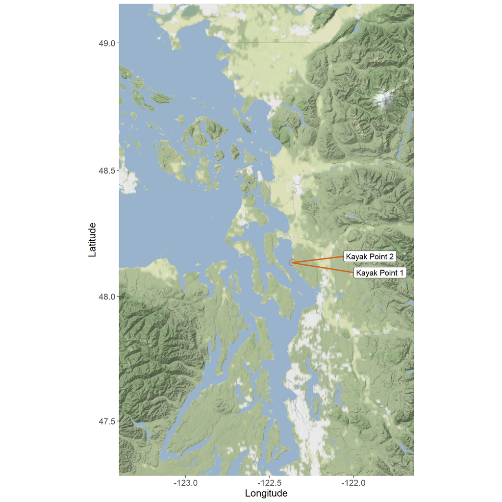

**Table 1.** The number of crab sampled for each sampling date.

| Site | Date | Crab Sampled (N) |
| --- | --- | --- |
| Kayak Point 1 | 7/23/2021 | 8 |
| Kayak Point 1 | 8/19/2021 | 6 |
| Kayak Point 1 | 8/20/2021 | 1 |
| Kayak Point 1 | 8/5/2021 | 1 |
| Kayak Point 1 | 8/6/2021 | 1 |
| Kayak Point 2 | 8/6/2021 | 12 |

Across all individuals in Port Susan Bay, the average carapace width was 8.6 and the average carapace height was 7.8.

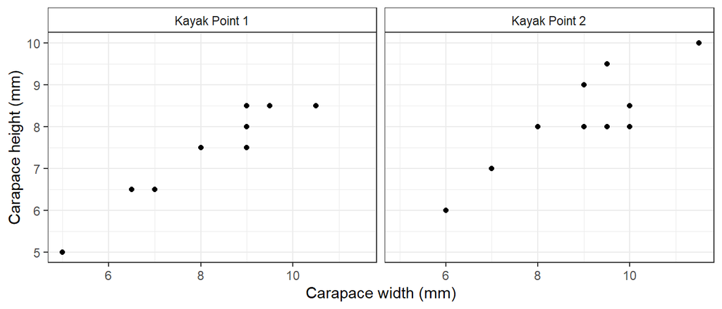

We detected a number of unicellular organisms in crab stomach contents, including those which commonly occur as small phytoplankton and zooplankton in marine and brackish waters. Field observations suggest early instar Dungeness crab may consume diatoms and algal epiphytes, and laboratory studies have shown it is possible for J1-3 instars to grow and molt on a diet of pure filamentous diatoms, or diatoms mixed with naturally-occurring microorganisms (Jensen & Asplen, 1998). However, there is some question about the energetic value of certain of these small phyto- and zooplankton (G. C. Jensen & Asplen, 1998). We therefore provide some summaries (e.g., **Table 2**) and analyses separately for single- versus multi-cellular prey items; to more clearly communicate which prey items we include for each analysis, we specify whether the analysis was run on “all taxa” (both single- and multi-cellular prey items), “single-celled organisms,” or “multi-cellular prey.”

**Table 2.** The number of crab sampled which contained putative prey items.

| Site | Crab Sampled (N) | Crab with Prey (all) | with Prey (single-celled) | with Prey (multi-cellular) |
| --- | --- | --- | --- | --- |
| Kayak Point 1 | 17 | 12 | 12 | 12 |
| Kayak Point 2 | 12 | 10 | 9 | 10 |